# Likelihood Function Core code

Generating some data with a know probability of germination -> myP

```r
myP<-0.67
myData<-rbinom(n=10,size=1,prob=myP)
myData
```

```
##  [1] 1 0 0 1 0 1 1 0 1 1
```

```r
mean(myData)
```

```
## [1] 0.6
```

Here is the form of the Likelihood Functions that we have been using to fit models. This is specific to the Binomial probability function.

```r
nllBinomial<-function(parmEstimate,seedlingDat){

  nllik<- -sum(dbinom(seedlingDat,size=1,parmEstimate,log=TRUE))

  cat("nllik= ",nllik,sep=" ",fill=T)
  return(nllik)
}

nllBinomial(0.6,myData)
```

```
## nllik=  6.730117
```

```
## [1] 6.730117
```

```r
nllBinomial(0.1,myData)
```

```
## nllik=  14.23695
```

```
## [1] 14.23695
```

We would then minimize the function using optim().

```r
parVec<-c(0.1) # Initial parameter values
outLogReg<-optim(par=parVec,fn=nllBinomial,method="L-BFGS-B",lower=c(0.01),upper=c(0.99),seedlingDat=myData)
```

```
## nllik=  14.23695
## nllik=  14.1817
## nllik=  14.29281
## nllik=  18.48098
## nllik=  18.48098
## nllik=  18.10581
## nllik=  6.734202
## nllik=  6.733643
## nllik=  6.734801
## nllik=  6.731772
## nllik=  6.731423
## nllik=  6.732162
## nllik=  6.730117
## nllik=  6.730142
## nllik=  6.730134
## nllik=  6.730117
## nllik=  6.730137
## nllik=  6.730138
## nllik=  6.730117
## nllik=  6.730138
## nllik=  6.730138
```

```r
outLogReg$par #
```

```
## [1] 0.5999997
```

The core portion of the likelihood function is this line of code:

nllik<- -sum(dbinom(seedlingDat,size=1,parmEstimate,log=TRUE))

I want to step through this line of code so that its clear what its doing.

dataVector<-c(1,0,1)

where 1 indicates a seed produced a seedling and 0 indicates no seedling emerged.

So the likelihood is the likelihood of observing a 1, 0, and 1 given some germination probability,G.

Likelihood = P(1|G) * P(0|G) * P(1|G) where the P() is the binomial distribution. For the binomial distribution, we have to specify the size of the trials. For each of our ‘trials’, we plant a single seed and observe if a seedling emerges, So the size of our trial is 1, because we plant a single seed.

We next choose a value of G, then calculate the likelihood of observing our data as follows:

```r
G<-0.10
dbinom(1,size=1,G) * dbinom(0,size=1,G) * dbinom(1,size=1,G)
```

```
## [1] 0.009
```

```r
G<-0.7
dbinom(1,size=1,G) * dbinom(0,size=1,G) * dbinom(1,size=1,G)
```

```
## [1] 0.147
```

```r
G<-0.9
dbinom(1,size=1,G) * dbinom(0,size=1,G) * dbinom(1,size=1,G)
```

```
## [1] 0.081
```

By taking the logs of each of these probabilities, we add them together rather than multiply them. This helps avoid numerical issues associated with getting very small numbers from multiplying long sequences of probabilities together. Eventually, the computer will just say that the final product is 0.

So we modify the above code by setting log=T and then adding the terms together.

```r
G<-0.10
dbinom(1,size=1,G, log=T) + dbinom(0,size=1,G, log=T) + dbinom(1,size=1,G, log=T)
```

```
## [1] -4.710531
```

```r
G<-0.7
dbinom(1,size=1,G, log=T) + dbinom(0,size=1,G, log=T) + dbinom(1,size=1,G, log=T)
```

```
## [1] -1.917323
```

```r
G<-0.9
dbinom(1,size=1,G, log=T) + dbinom(0,size=1,G, log=T) + dbinom(1,size=1,G, log=T)
```

```
## [1] -2.513306
```

Finally, we want to be able to compute the likelihood over a set of alternative values of G. The value of G that produces the highest likelihood is the most likely value or maximum likelihood estimate (mle).

In the code below, I create a sequence of values of G, then calculate the likelihood associated with each of these values.

Note that I am using the map_dbl function from the purrr library. The map_dbl function applies the myLike function to each value of G.

```r
library(purrr)

G<-seq(from=0, to=1,by=0.10)

myLike<-function(G) {dbinom(1,size=1,G, log=T) + dbinom(0,size=1,G, log=T) + dbinom(1,size=1,G, log=T) }

map_dbl(G,myLike)
```

```
##  [1]      -Inf -4.710531 -3.442019 -2.764621 -2.343407 -2.079442 -1.937942
##  [8] -1.917323 -2.055725 -2.513306      -Inf
```

Since the dbinom function can be vectorized, we can simplify this calculation as follows

```r
G<-0.1
dataVector<-c(1,0,1)
sum(dbinom(dataVector,size=1, G, log=T))
```

```
## [1] -4.710531
```

so that our code above becomes

```r
library(purrr)

dataVector<-c(1,0,1)
G<-seq(from=0, to=1,by=0.10)

myLike2<-function(G) {sum(dbinom(dataVector,size=1, G, log=T)) }

map_dbl(G,myLike2)
```

```
##  [1]      -Inf -4.710531 -3.442019 -2.764621 -2.343407 -2.079442 -1.937942
##  [8] -1.917323 -2.055725 -2.513306      -Inf
```

Finally, we add a minus sign in front of the sum to calculate the negative log likelihood, so that we can minimize the function using optim() rather than maximize it.

```r
library(purrr)

dataVector<-c(1,0,1)
G<-seq(from=0, to=1,by=0.10)

myLike2<-function(G) {-sum(dbinom(dataVector,size=1, G, log=T)) }

nllVector<-map_dbl(G,myLike2)
nllVector
```

```
##  [1]      Inf 4.710531 3.442019 2.764621 2.343407 2.079442 1.937942 1.917323
##  [9] 2.055725 2.513306      Inf
```

Now we can plot the likelihood function. Its not smooth because we have a small number of values of G that we are using. The more values of G that we use, the smoother the function will become.

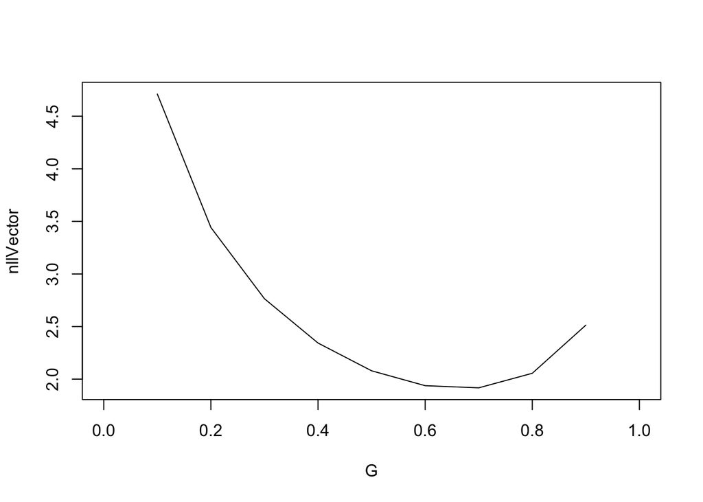

```r
plot(G,nllVector,typ='l')
```